# Reproducible Research: Peer Assessment 1

kai he

Thursday, August 06, 2015

### Loading and preprocessing the data

- You need download the data file from the site provide in the assignment page.
- Unzip and save the data file in your working directory
- Check data’s properties
- Create final dataset which has no NA
- Get sum of total steps per day

```r
theFile <- "activity.csv"
data <- read.csv(theFile,sep=",",header=TRUE,stringsAsFactor=FALSE)
str(data)
```

```
## 'data.frame':    17568 obs. of  3 variables:
##  $ steps   : int  NA NA NA NA NA NA NA NA NA NA ...
##  $ date    : chr  "2012-10-01" "2012-10-01" "2012-10-01" "2012-10-01" ...
##  $ interval: int  0 5 10 15 20 25 30 35 40 45 ...
```

```r
head(data)
```

```
##   steps       date interval
## 1    NA 2012-10-01        0
## 2    NA 2012-10-01        5
## 3    NA 2012-10-01       10
## 4    NA 2012-10-01       15
## 5    NA 2012-10-01       20
## 6    NA 2012-10-01       25
```

```r
dim(data)
```

```
## [1] 17568     3
```

```r
fd <- data[complete.cases(data),]
dateagg <- aggregate(fd$steps, list(fd$date), sum)
names(dateagg) <- c("Date", "Steps")
```

### What is mean total number of steps taken per day?

#### 1. Histogram of the total number of steps taken each day

- You may receive the error message regarding to the packages, so you need to install the necessary packages in order to be able run knit HTML successfully.

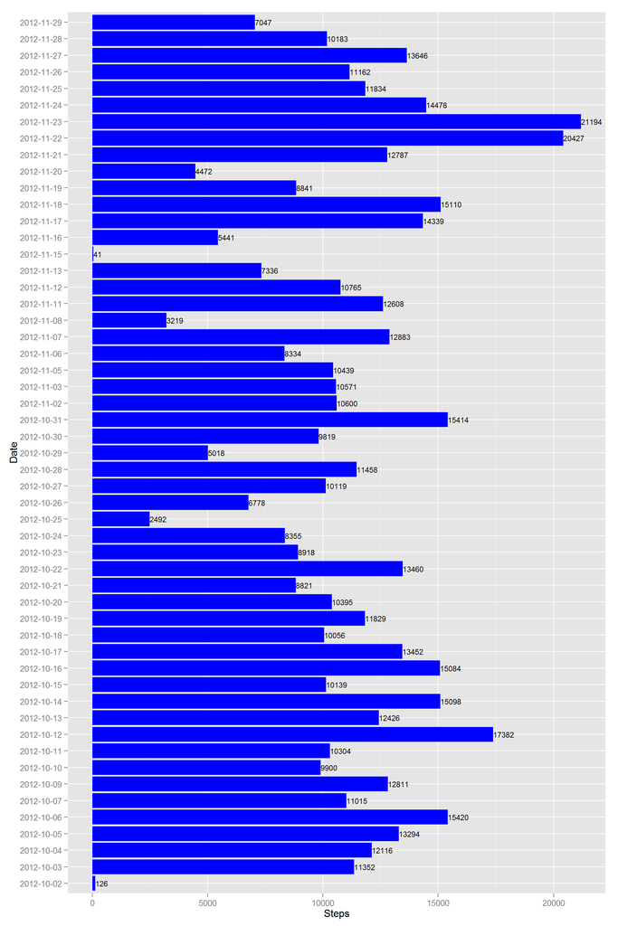

```r
require(ggplot2)
ggplot(dateagg, aes(x=Date, y=Steps)) +
  geom_histogram(stat="identity", binwidth=0.2, fill="blue",label=TRUE) +
  geom_text(aes(label=Steps),size=3,hjust=0) +
  coord_flip()
```

#### 2. Means of total number of steps taken per day

- The mean and median total number of steps taken per day

```r
require(dplyr)
require(sqldf)
require(tcltk)
grouped <- group_by(fd, date)
output <- summarise(grouped,
                    sum=sum(steps),
                    mean=mean(steps),
                    median=median(steps))
sqldf('select date, mean, median from output')
```

```
##          date       mean median
## 1  2012-10-02  0.4375000      0
## 2  2012-10-03 39.4166667      0
## 3  2012-10-04 42.0694444      0
## 4  2012-10-05 46.1597222      0
## 5  2012-10-06 53.5416667      0
## 6  2012-10-07 38.2465278      0
## 7  2012-10-09 44.4826389      0
## 8  2012-10-10 34.3750000      0
## 9  2012-10-11 35.7777778      0
## 10 2012-10-12 60.3541667      0
## 11 2012-10-13 43.1458333      0
## 12 2012-10-14 52.4236111      0
## 13 2012-10-15 35.2048611      0
## 14 2012-10-16 52.3750000      0
```

[output cut: 39 more lines]

### What is the average daily activity pattern?

#### 1.Make a time series plot (i.e. type = “l” ) of the 5-minute interval (x-axis) and the average number of steps taken, averaged across all days (y-axis)

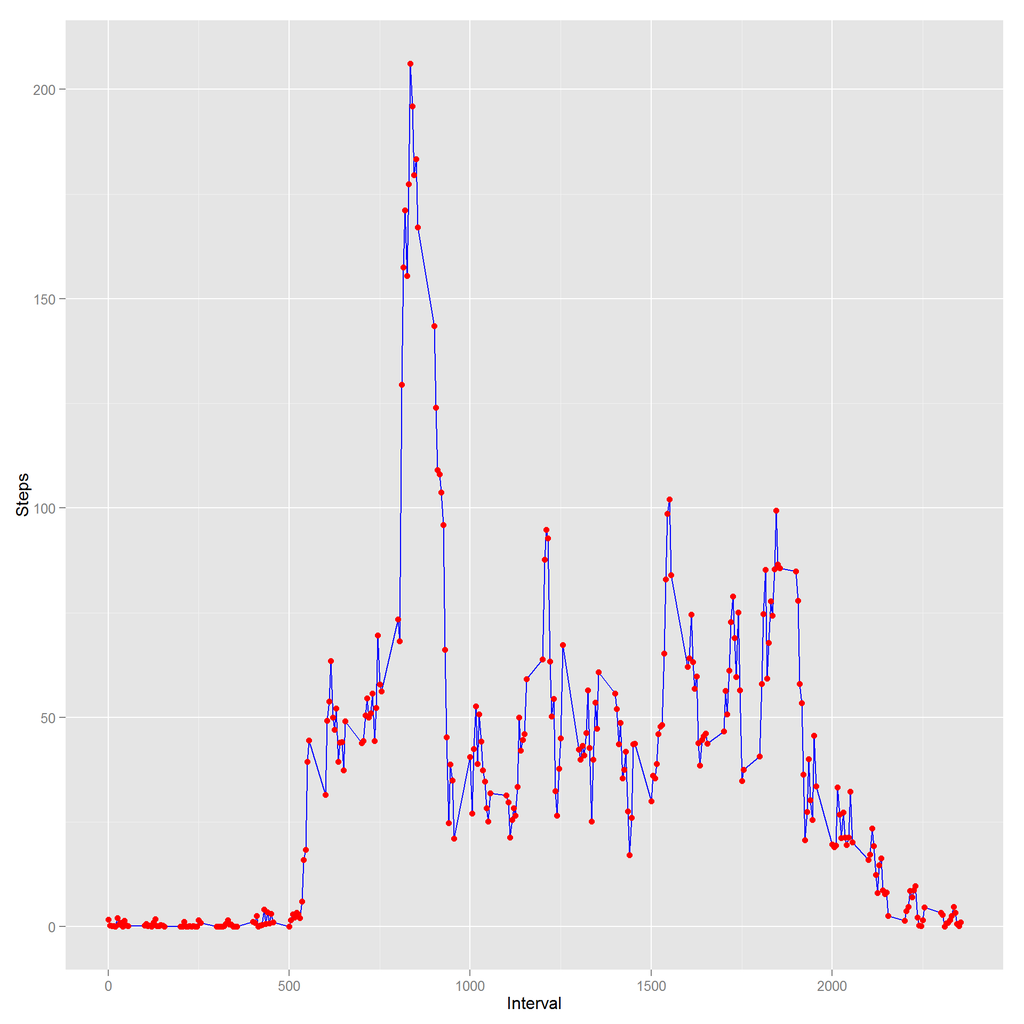

```r
require(ggplot2)
output2 <- aggregate(fd$steps, list(fd$interval), mean)
names(output2) <- c("Interval", "Steps")
ggplot(output2, aes(x=Interval, y=Steps)) +
  geom_line(col='blue') +
  geom_point(col='red')
```

```r
grouped2 <- group_by(fd, interval)
output2 <- summarise(grouped2,
                    sum=sum(steps),
                    max=max(steps),
                    mean=mean(steps))
subset(output2[,c(1,3)],output2$max==max(output2$max))
```

```
## Source: local data frame [1 x 2]
##
##   interval max
## 1      615 806
```

### Imputing missing values

- 1. Total missing and NA data in the data set is:

```r
total_miss = sum(is.na(data[1])) + sum(is.na(data[2])) + sum(is.na(data[3]))
print(total_miss)
```

```
## [1] 2304
```

- 2. Devise a strategy for filling in all of the missing values in the dataset…. Don’t know what is that mean, because the original data has missing value already. Or we need to remove some rows or records? or here NA = missing data? without clear this, here I use the original data as the data set with missing data (actually it does have) for the following calculation and plotting.
- 3. The original data already has missing data, why need another dataset with mssing data? Don’t understand this as well
- 4. 1 Make a histogram of the total number of steps taken each day

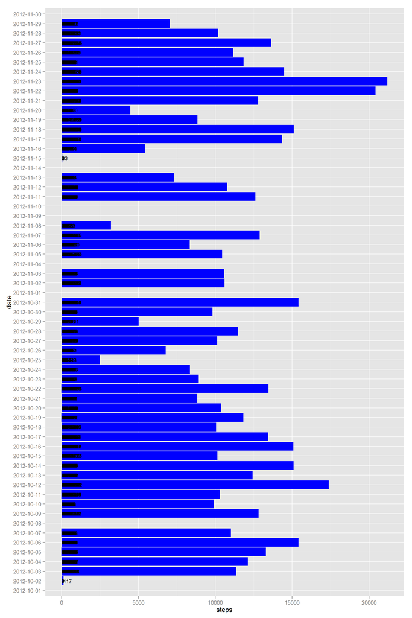

```r
require(ggplot2)
ggplot(data, aes(x=date, y=steps)) +
  geom_histogram(stat="identity", binwidth=0.2, fill="blue",label=TRUE) +
  geom_text(aes(label=steps),size=3,hjust=0) +
  coord_flip()
```

- 4. 2 Calculate and report the mean and median total number of steps taken per day

```r
grouped <- group_by(data, date)
output4 <- summarise(grouped,
                    sum=sum(steps),
                    mean=mean(steps),
                    median=median(steps))
sqldf('select date, mean, median from output4')
```

```
##          date       mean median
## 1  2012-10-01         NA     NA
## 2  2012-10-02  0.4375000      0
## 3  2012-10-03 39.4166667      0
## 4  2012-10-04 42.0694444      0
## 5  2012-10-05 46.1597222      0
## 6  2012-10-06 53.5416667      0
## 7  2012-10-07 38.2465278      0
## 8  2012-10-08         NA     NA
## 9  2012-10-09 44.4826389      0
## 10 2012-10-10 34.3750000      0
## 11 2012-10-11 35.7777778      0
## 12 2012-10-12 60.3541667      0
## 13 2012-10-13 43.1458333      0
## 14 2012-10-14 52.4236111      0
```

[output cut: 47 more lines]

```r
fd$WD <- factor((weekdays(as.Date(fd$date)) %in% c("Saturday", "Sunday")),
                levels=c(TRUE,FALSE),
                labels=c("weekend","weekday"))
wkd <- nrow(fd[fd$WD == "weekend",])
wky <- nrow(fd[fd$WD == "weekday",])
# sanity test: sum of weekday and weekend = sum of subset data without NA, i.e 15264
# the original data set size = 17568
# the missing or NA data size = 2304 (see above)
wkd + wky
```

```
## [1] 15264
```

- 2.Make a panel plot containing a time series plot

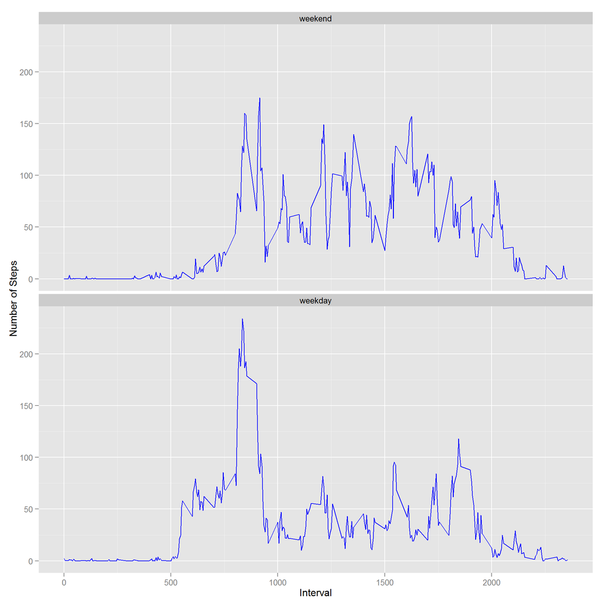

```r
require(ggplot2)
output3 <- aggregate(fd$steps, list(fd$interval, fd$WD), mean)
ggplot(output3, aes(x=Group.1, y=x)) +
  geom_line(type="l", col='blue') +
  labs(x="Interval", y="Number of Steps") +
  facet_wrap(~ Group.2, ncol=1)
```

From the plots of weekday and weekend, we can see betwee 500 to 1000 interval the steps in weekday are higher then the one in weekend, between 1000 to 2000 interval, the steps in weekend are relatively higher than the one in weekday.